# HSC Survey Results

# Scots Bay Survey # 5 Results from 05/07/2026

## Survey Details

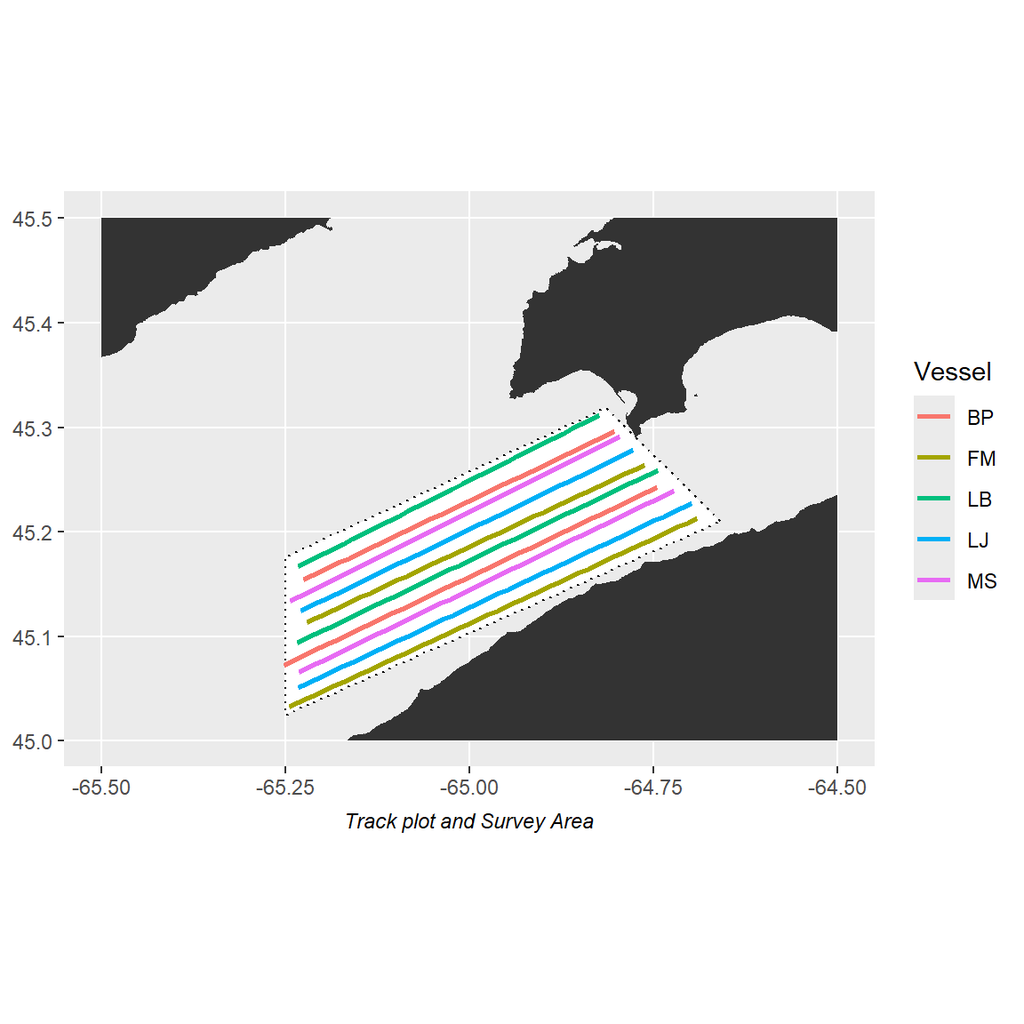

5 commercial purse seiners conducted this fishing survey on 05/07/2026 starting at 21:00:00, which was 4.92 hour after high tide.

All vessels ran two transects each in the Main Survey Box.

There was a plankton tow and replicate conducted and CTD cast by Lady Janice II.

No tags were applied during this survey.

Samples were obtained for target strength estimation.

### Tides Tables

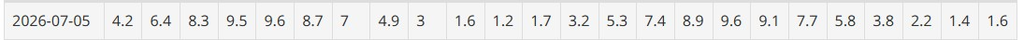

Tide Schedule for Margaretsville NS, Station #315m Source: www.waterlevels.gc.ca

### Acoustic Equipment

Each vessel was equipped with a Simrad ES38-18/200-18C combi (2-in-1) transducer prior to the survey that contains a 38kHz split beam and 200 kHz single beam transducer. Data was logged to the computer hard-drive for post-processing. All participating boats were calibrated on 38kHz before the survey.

## Survey Results

### Main Results

The results are subject to change as DFO will re-evaluate data editing, area estimation and apply a target strength.

**Preliminary biomass prediction for Scots Bay using standardized parallel transects is 20,280mt, and with turnover applied 14,137mt.**

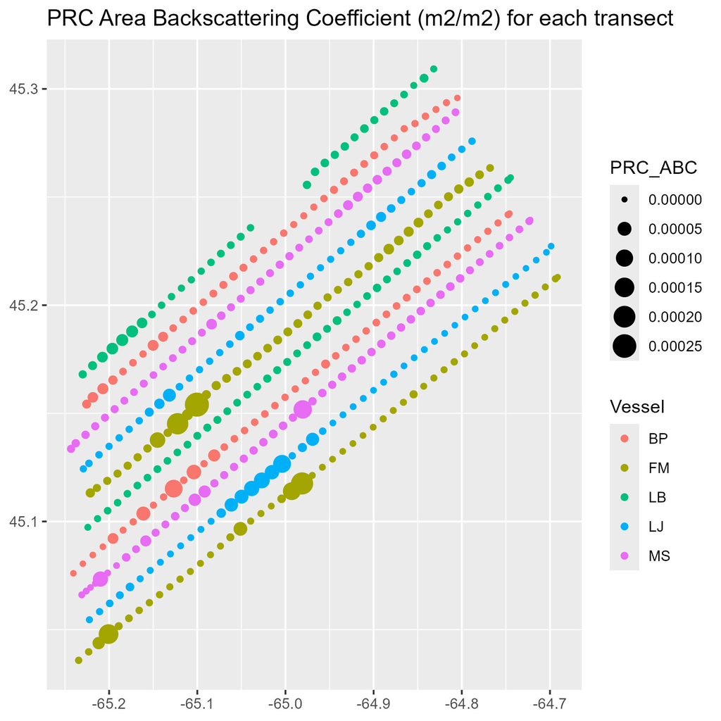

### Transect Details

Table 1: Transect Details

| Vessel | Transect # | Date/Time Start | Date/Time End | Start Lon | Start Lat | End Lon | End Lat | Location | Distance (km) | Speed |
| --- | --- | --- | --- | --- | --- | --- | --- | --- | --- | --- |
| BP | T01 | 2026-07-05 19:51:34 | 2026-07-05 22:57:09 | -65.252 | 45.073 | -64.746 | 45.242 | SB | 44.09 | 7.70 |
| BP | T02 | 2026-07-05 23:24:19 | 2026-07-06 01:40:03 | -64.804 | 45.296 | -65.226 | 45.154 | SB | 36.79 | 8.78 |
| FM | T01 | 2026-07-05 21:42:38 | 2026-07-06 00:47:39 | -65.245 | 45.033 | -64.691 | 45.213 | SB | 48.10 | 8.42 |
| FM | T02 | 2026-07-06 01:15:34 | 2026-07-06 03:52:13 | -64.763 | 45.264 | -65.221 | 45.113 | SB | 40.08 | 8.29 |
| LB | T01 | 2026-07-05 20:14:28 | 2026-07-05 23:25:18 | -65.234 | 45.094 | -64.745 | 45.259 | SB | 43.20 | 7.33 |
| LB | T02 | 2026-07-06 00:12:56 | 2026-07-06 03:00:33 | -64.824 | 45.312 | -65.233 | 45.167 | SB | 37.34 | 7.22 |
| LJ | T01 | 2026-07-05 20:49:55 | 2026-07-05 23:47:09 | -65.233 | 45.051 | -64.699 | 45.227 | SB | 46.54 | 8.51 |
| LJ | T02 | 2026-07-06 00:18:55 | 2026-07-06 02:57:10 | -64.778 | 45.278 | -65.229 | 45.124 | SB | 39.45 | 8.08 |
| MS | T01 | 2026-07-05 20:58:15 | 2026-07-06 00:30:14 | -65.232 | 45.066 | -64.722 | 45.239 | SB | 48.35 | 7.39 |
| MS | T02 | 2026-07-06 01:03:55 | 2026-07-06 03:48:01 | -64.796 | 45.291 | -65.243 | 45.134 | SB | 40.46 | 7.99 |

### Survey Summary

Table 2: Acoustic Survey Results

| Vessel | Transect No. | Target Strength (db/kg) | Mean Sa (/m2) | Biomass Density (kg/m2) |
| --- | --- | --- | --- | --- |
| FM | T02 | -35.5 | -47.111 | 0.069 |
| FM | T01 | -35.5 | -49.084 | 0.044 |
| LJ | T01 | -35.5 | -49.623 | 0.039 |
| MS | T01 | -35.5 | -50.382 | 0.032 |
| BP | T01 | -35.5 | -51.307 | 0.026 |
| LB | T02 | -35.5 | -52.056 | 0.022 |
| MS | T02 | -35.5 | -53.166 | 0.017 |
| LJ | T02 | -35.5 | -53.657 | 0.015 |
| BP | T02 | -35.5 | -53.845 | 0.015 |
| LB | T01 | -35.5 | -55.762 | 0.009 |

Note:  
Transects are listed from greatest to least backscatter.

Table 3: Survey Summary Table

| Layer | Target Strength | Area (km2) | Mean Sa | Density (kg/m2) | Biomass (tons) | Percent Area | Percent Biomass | Standard Error (tons) | Standard Error (%) |
| --- | --- | --- | --- | --- | --- | --- | --- | --- | --- |
| Main Box | -35.5 | 690.26490 | -50.8195 | 0.0289 | 20,280.02 | NA | NA | 3,918.51 | 19.32 |
| Northern Box | NA | 80.94466 | NA | NA | NA | NA | NA | NA | NA |
| Eastern Box | NA | NA | NA | NA | NA | NA | NA | NA | NA |

### Greatest Biomass Densities

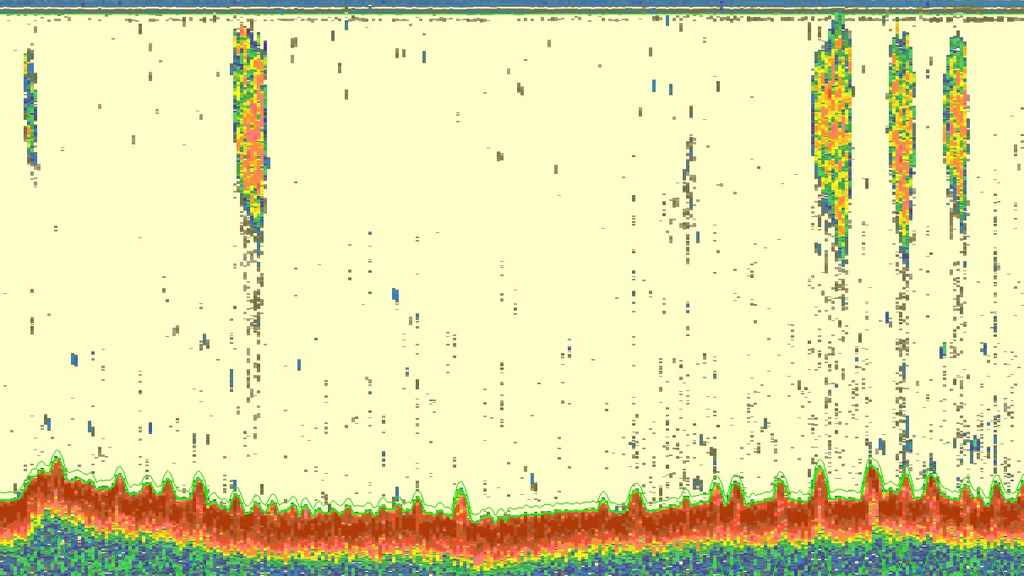

A snip from the transect with the greatest biomass density (kg/m2)

The single point with the largest biomass density (kg/m2) was recorded by **FM**, at the following location:

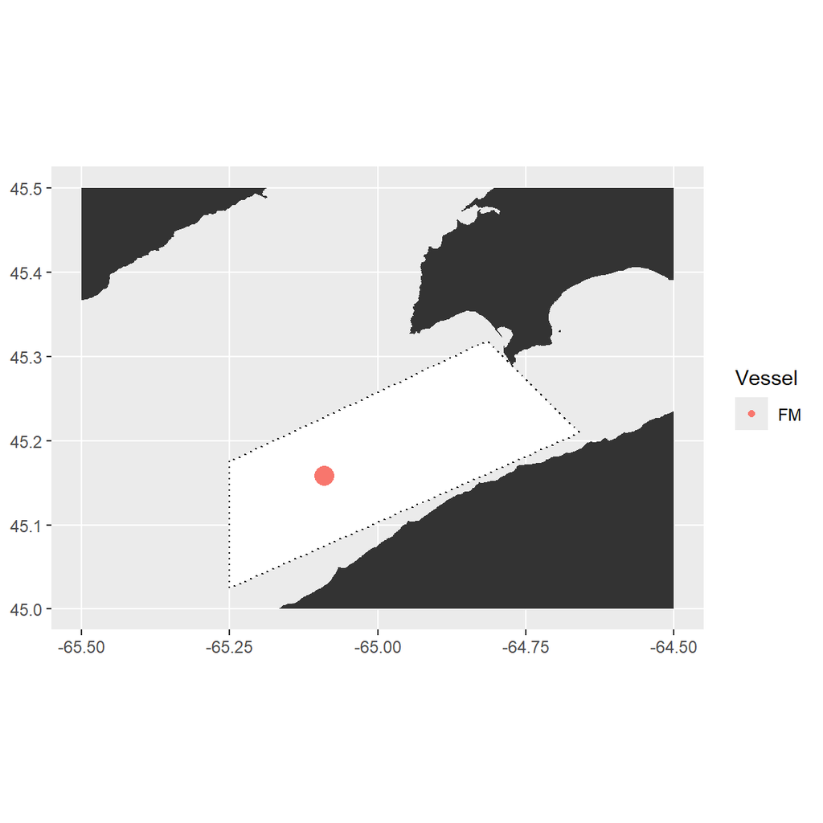

The transect with the greatest average biomass density (kg/m2) was recorded by **FM**, at the following location:

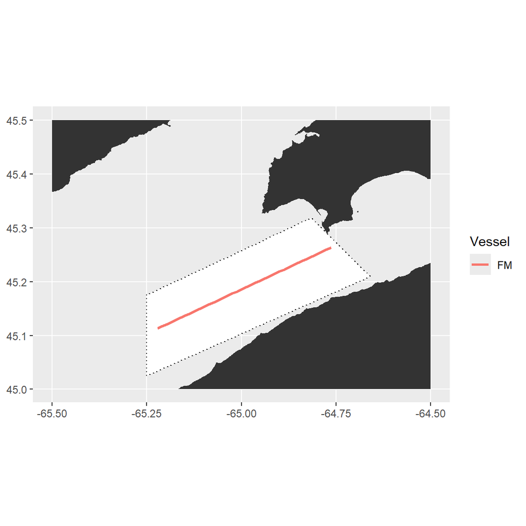

### Annual Summaries

This table does not include the biomass from adhoc surveys.

Table 4: Annual Comparison Table

| Ground | Survey Number | Current Year Survey Date | Current Year HSC Estimate | Current Year HSC Turnover Adjusted | Previous Year Survey Date | Previous Year HSC Estimate | Previous Year HSC Turnover Adjusted | Previous Year DFO Estimate | Previous Year DFO Turnover Adjusted |
| --- | --- | --- | --- | --- | --- | --- | --- | --- | --- |
| Scots Bay | 1 | 2026-05-10 | 29,384.00 | 29,384 | 2025-05-06 | 12,306 | 12,306 | NA | NA |
| Scots Bay | 2 | 2026-05-24 | 61,138.00 | 57,169 | 2025-05-20 | 120,045 | 118,023 | NA | NA |
| Scots Bay | 3 | 2026-06-07 | 48,291.00 | 39,929 | 2025-06-03 | 123,037 | 109,821 | NA | NA |
| Scots Bay | 4 | 2026-06-21 | 44,217.00 | 37,478 | 2025-06-16 | 14,184 | 0 | NA | NA |
| Scots Bay | 5 | 2026-07-05 | 20,280.02 | 14,137 | 2025-06-30 | 15,789 | 11,509 | NA | NA |
| Scots Bay | 6 | NA | NA | NA | 2025-07-14 | 7,114 | 5,137 | NA | NA |
| Scots Bay | 7 | NA | NA | NA | 2025-07-28 | 7,573 | 6,612 | NA | NA |
| Scots Bay | 8 | NA | NA | NA | 2025-08-11 | 5,164 | 4,916 | NA | NA |
| Scots Bay | 9 | NA | NA | NA | 2025-08-26 | 6,675 | 5,948 | NA | NA |
| Scots Bay | 10 | NA | NA | NA | 2025-09-08 | 4,180 | 3,169 | NA | NA |
| Scots Bay | 11 | NA | NA | NA | 2025-09-21 | 11,201 | 10,471 | NA | NA |

Table 5: Annual Summary Table

| Year | Ground | HSC Estimate | HSC Turnover Adjusted | DFO Estimate | DFO Turnover Adjusted |
| --- | --- | --- | --- | --- | --- |
| 2025 | Scots Bay | 327,268 | 287,912 | NA | NA |
| 2026 | Scots Bay | 203,310 | 178,097 | NA | NA |

## Vessel Performance

### Speed

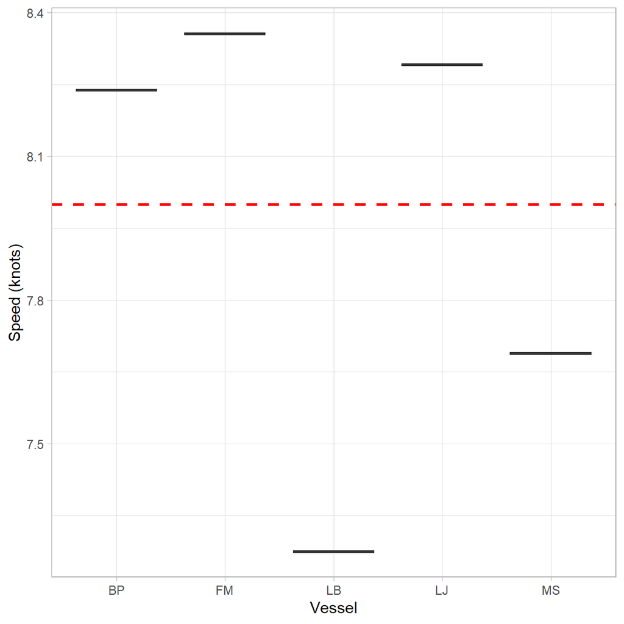

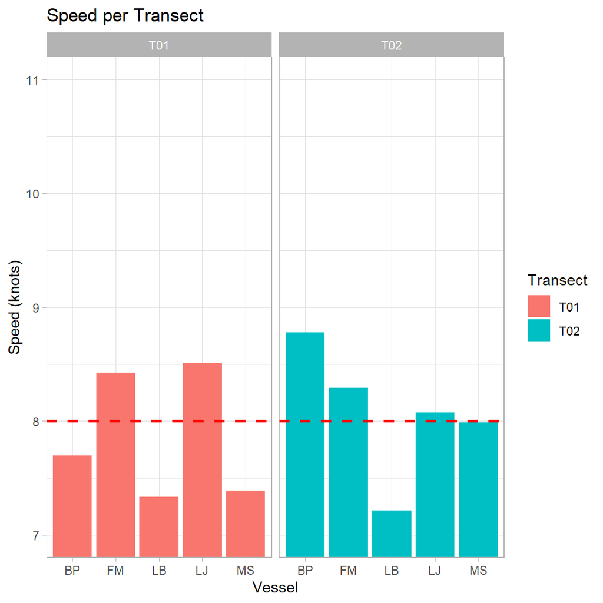

The vessels performed well and the average vessel speed was 7.97 which is below the requirements of 8 knots.

The speed for each transect are rudimentary and are calculated based on distance. If a significant amount of distance is cut, the speed will appear slower.